**M1 Project Report**

**Probability Theory and Introductory Statistics**

ALY 6010 - 71579

**Maheswar Raju Narasaiah**

Prof: Dr. Dee Chiluiza

Date:10 November, 2022

# 1. Introduction

# 2. Analysis

In this section, we will perform analysis on various types of variables to gain insight and address our problems

Task 2. • Prepare and present a bar plot to show the frequencies of each category of variable location.  
• Prepare and present a pie chart to show the Percentages of each category of variable fuel type. Important: Use code par(mfcol=c(1,2)) to organize your bar plots presentation in a 1x2 matrix.  
• Improve your graphs presentation with clear y- and x- axes labels, colors.  
Write some observations of your figure.

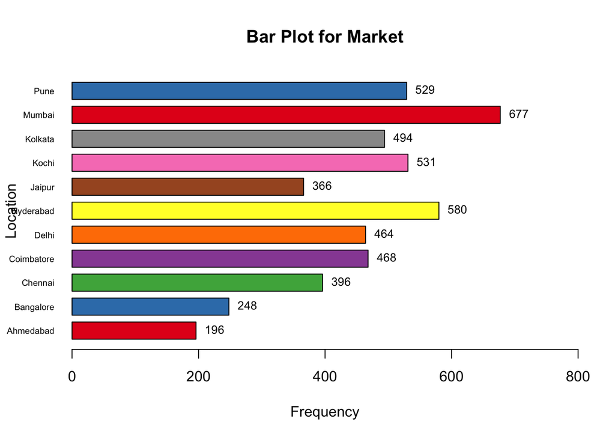

```r
#Table Creation of Lacation for Bar Graph
tbar3.1 = table(CarSales$Location)

plotMarket = barplot(tbar3.1, main="Bar Plot for Market",
                 ylab = "Location",
                 xlab = "Frequency",
                col = brewer.pal(15, "Set1"),
                border = "black",
                xlim = c(0,800),
                 las = 1.5,
                cex.lab = 1,
                cex.axis = 1,
                 cex.names = 0.6,
                 horiz = T,
                 space = 0.4)

#Adding Lables
text(x=tbar3.1,
     plotMarket,
     tbar3.1,
     cex=0.8,
     pos = 4)
```

[figure not shown]

```r
#Table Creation of Shipping Mode for Pie Chart

t17piechart  <- table(CarSales$FuelType)

#Lable Creation for Pie Chart
pieLabel4 = paste( unique(sort(CarSales$FuelType)),":", sort(t17piechart),"(",round(100 * t17piechart/sum(t17piechart), 2),"%",")")


# Plot the pie chart for ship mode.
pie1 = pie(t17piechart, labels = pieLabel4,
           radius = 0.6,
           col =  brewer.pal(7, "Dark2"),
    border = "white",
    lty = 1,
    cex=0.8,
    font = 3,
    clockwise = T)

legend("topleft",
       legend = paste(unique(sort(CarSales$FuelType))),
       fill = brewer.pal(7, "Dark2"),
       border = "white")
box(col="black")


box(col="black")
```

Task 3  
Create a table with the variable Owner on the rows, and present their corresponding frequencies, cumulative frequencies, percentages, and cumulative percentages.  
Notice that your table contains 5 columns, plus the labels for each row.  
If you have decimals, always reduce them to 2 or 3 only. Follow these steps: • Create a table to present locations and its frequencies.  
• Convert table using as.data.frame() • Rename columns: Var1 to Location and Freq to Frequency. • Use code mutate() to create three new columns (these are new calculated fields): • The cumulative frequencies, name column: CumFrequency. • The percentages, name column: Percentage • The cumulative percentage, name column: CumPercentage

Present it using the library(knitr). , in this case knitr::kable().  
Optional: practice these codes to present your table, you will need to install package kableExtra.

knitr::kable(digits = 2, caption = “Task 3 Table”) %>% kable_classic(full_width = FALSE, font_size = 12) Check: https://cran.r-project.org/web/packages/kableExtra/vignettes/awesome_table_in_html.html.  
Write some observations of your figure.

```r
# Create the vector for Frequency, Cumulative Frequency, Probability, Cumulative Probability

t15prod <- CarSales$Owner %>%
  table()%>%
  as.data.frame() %>%
  rename(Column1 = Freq) %>%
  mutate(Column2 = cumsum(Column1),
         Column3 = (Column1/nrow(CarSales))*100,
         Column4 = cumsum(Column3))


#Present the table
knitr::kable(t15prod,
             digits = 2,
            caption = "Frequency distribution for Owner Category",
            col.names =  c("Owner","Frequency", "Cumulative Frequency", "Percentage", "Cumulative Percentage"),
             format = "html",
             table.attr="style=width: 40%",align = "c")%>%
kable_styling(bootstrap_options = c("striped", "hover", "condensed", "responsive")) %>%
kable_classic(full_width = TRUE, position ="center", font_size = 12)
```

Frequency distribution for Owner Category

| Owner | Frequency | Cumulative Frequency | Percentage | Cumulative Percentage |
| --- | --- | --- | --- | --- |
| First | 2921 | 2921 | 59.02 | 59.02 |
| Fourth | 782 | 3703 | 15.80 | 74.82 |
| Second | 916 | 4619 | 18.51 | 93.33 |
| Third | 330 | 4949 | 6.67 | 100.00 |

Task 5 • Prepare one horizontal box plot and one histogram to display the data distribution of the continuous numerical variable kilometers. • Use the code par(mfrow=c(2,1), mai=(1,1,1,1)) at the beginning of the R chunk.  
• mfrow will present the two figures one of top of the other as a group, in this case, c(2,1) indicates 2 rows and 1 column. Mai will change the margins of your figures, bottom, left. Top. Right. Play with the mai numbers to observe changes.  
• Remove the title of your graphs by using main = NA.